# customer_engagement_analysis

Ife Abe

2024-11-26

## 1 Introduction

This document analyzes customer engagement data for PalletTrader, focusing on **Buyers** and **Sellers**. The goal is to identify patterns in transaction behavior, customer retention, and high-value customers.

## 2 Generate Synthetic Data

```r
# Set seed for reproducibility
set.seed(123)

# Number of participants
n_customers <- 500

# Generate synthetic dataset
customer_data <- data.frame(
  CustomerID = 1:n_customers,
  CustomerType = sample(c("Buyer", "Seller"), n_customers, replace = TRUE), # Buyer or Seller
  TransactionType = sample(c("Purchase", "Sale"), n_customers, replace = TRUE), # Purchase or Sale
  TransactionCount = sample(1:20, n_customers, replace = TRUE), # Number of transactions
  AvgTransactionValue = round(runif(n_customers, 50, 500), 2), # Transaction value in USD
  SatisfactionScore = sample(1:5, n_customers, replace = TRUE) # Satisfaction on a scale of 1 to 5
)

# Add calculated fields
customer_data <- customer_data %>%
  mutate(
    TotalTransactionValue = TransactionCount * AvgTransactionValue, # Total transaction value
    HighValueCustomer = ifelse(TotalTransactionValue > 3000, "Yes", "No"), # High-value threshold
    Retained = sample(c("Yes", "No"), n_customers, replace = TRUE, prob = c(0.8, 0.2)), # Retention flag
    PrimaryRole = ifelse(CustomerType == "Buyer", "Procurement", "Supply") # Primary activity
  )

# View the first few rows of the dataset
head(customer_data)
```

```
##   CustomerID CustomerType TransactionType TransactionCount AvgTransactionValue
## 1          1        Buyer            Sale               13               81.50
## 2          2        Buyer            Sale                8              484.82
## 3          3        Buyer            Sale                2              215.72
## 4          4       Seller            Sale                6              354.85
## 5          5        Buyer        Purchase               17              430.68
## 6          6       Seller        Purchase               14              158.74
##   SatisfactionScore TotalTransactionValue HighValueCustomer Retained
## 1                 2               1059.50                No      Yes
## 2                 2               3878.56               Yes      Yes
## 3                 4                431.44                No       No
## 4                 2               2129.10                No      Yes
## 5                 3               7321.56               Yes      Yes
## 6                 4               2222.36                No       No
##   PrimaryRole
## 1 Procurement
## 2 Procurement
## 3 Procurement
## 4      Supply
## 5 Procurement
## 6      Supply
```

## 3 1. Overview of Buyers and Sellers

### 3.1 **Transaction Metrics by Customer Type**

We will now summarize transaction metrics for **Buyers** and **Sellers**. This includes average transaction count, average transaction value, and total transaction value.

```r
# Summarize transaction metrics by Customer Type
transaction_summary <- customer_data %>%
  group_by(CustomerType) %>%
  summarise(
    AvgTransactionCount = mean(TransactionCount),
    AvgTransactionValue = mean(AvgTransactionValue),
    TotalTransactionValue = sum(TotalTransactionValue),
    AvgSatisfactionScore = mean(SatisfactionScore)
  )

transaction_summary
```

```
## # A tibble: 2 × 5
##   CustomerType AvgTransactionCount AvgTransactionValue TotalTransactionValue
##   <chr>                      <dbl>               <dbl>                 <dbl>
## 1 Buyer                       10.7                276.               753680.
## 2 Seller                      10.6                270.               710205.
## # ℹ 1 more variable: AvgSatisfactionScore <dbl>
```

### 3.2 **Visualizing Transaction Metrics**

We will now visualize the average transaction value and total transaction value for **Buyers** and **Sellers**.

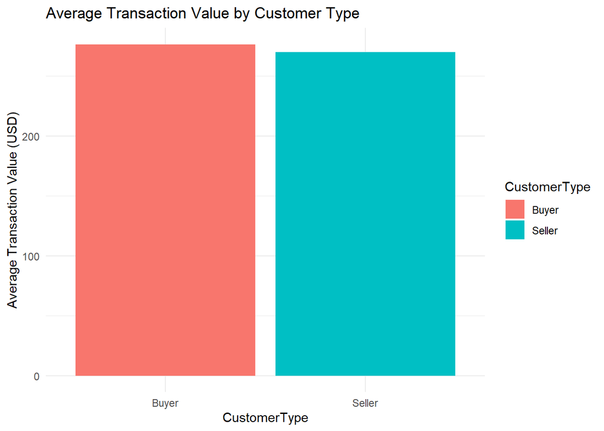

```r
# Bar plot for Average Transaction Value by Customer Type
ggplot(transaction_summary, aes(x = CustomerType, y = AvgTransactionValue, fill = CustomerType)) +
  geom_bar(stat = "identity", position = "dodge") +
  labs(title = "Average Transaction Value by Customer Type", y = "Average Transaction Value (USD)") +
  theme_minimal()
```

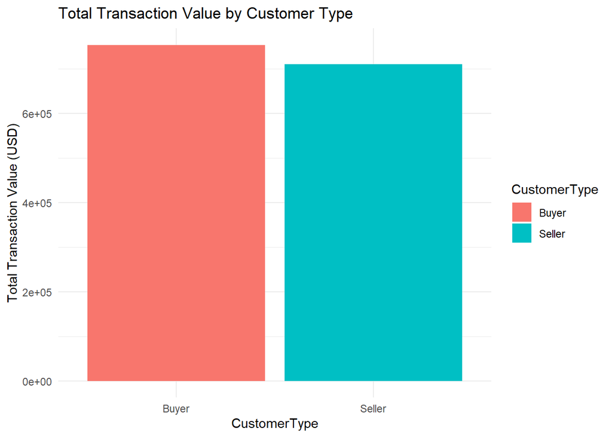

```r
# Bar plot for Total Transaction Value by Customer Type
ggplot(transaction_summary, aes(x = CustomerType, y = TotalTransactionValue, fill = CustomerType)) +
  geom_bar(stat = "identity", position = "dodge") +
  labs(title = "Total Transaction Value by Customer Type", y = "Total Transaction Value (USD)") +
  theme_minimal()
```

## 4 2. High-Value Customers

### 4.1 **Identifying High-Value Customers**

We define high-value customers as those with a total transaction value above $3000. Let’s filter out and analyze these customers.

```r
# High-value customers based on Total Transaction Value
high_value_customers <- customer_data %>%
  filter(HighValueCustomer == "Yes")

# Summary of High-Value Customers
high_value_summary <- high_value_customers %>%
  group_by(CustomerType) %>%
  summarise(
    AvgTotalTransactionValue = mean(TotalTransactionValue),
    AvgSatisfactionScore = mean(SatisfactionScore)
  )

high_value_summary
```

```
## # A tibble: 2 × 3
##   CustomerType AvgTotalTransactionValue AvgSatisfactionScore
##   <chr>                           <dbl>                <dbl>
## 1 Buyer                           5158.                 2.96
## 2 Seller                          5370.                 3.02
```

### 4.2 **Visualizing High-Value Customers**

We will visualize the proportion of high-value customers for **Buyers** and **Sellers**.

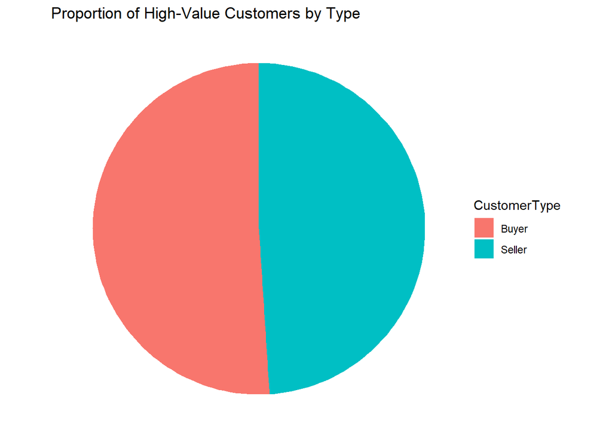

```r
# Pie chart for proportion of High-Value Buyers vs. Sellers
high_value_count <- customer_data %>%
  group_by(CustomerType, HighValueCustomer) %>%
  tally() %>%
  filter(HighValueCustomer == "Yes")

ggplot(high_value_count, aes(x = "", y = n, fill = CustomerType)) +
  geom_bar(stat = "identity", width = 1) +
  coord_polar(theta = "y") +
  labs(title = "Proportion of High-Value Customers by Type") +
  theme_void()
```

## 5 3. Retention Analysis

### 5.1 **Retention by Customer Type**

Let’s now analyze customer retention for **Buyers** and **Sellers**, comparing retention rates between these groups.

```r
# Retention analysis by Customer Type
retention_summary <- customer_data %>%
  group_by(CustomerType, Retained) %>%
  tally() %>%
  pivot_wider(names_from = Retained, values_from = n, values_fill = list(n = 0))

# Calculate retention rates
retention_summary <- retention_summary %>%
  mutate(
    RetentionRate = `Yes` / (`Yes` + `No`)
  )

retention_summary
```

```
## # A tibble: 2 × 4
## # Groups:   CustomerType [2]
##   CustomerType    No   Yes RetentionRate
##   <chr>        <int> <int>         <dbl>
## 1 Buyer           58   203         0.778
## 2 Seller          48   191         0.799
```

### 5.2 **Visualizing Retention Rates**

We will visualize the retention rates for **Buyers** and **Sellers**.

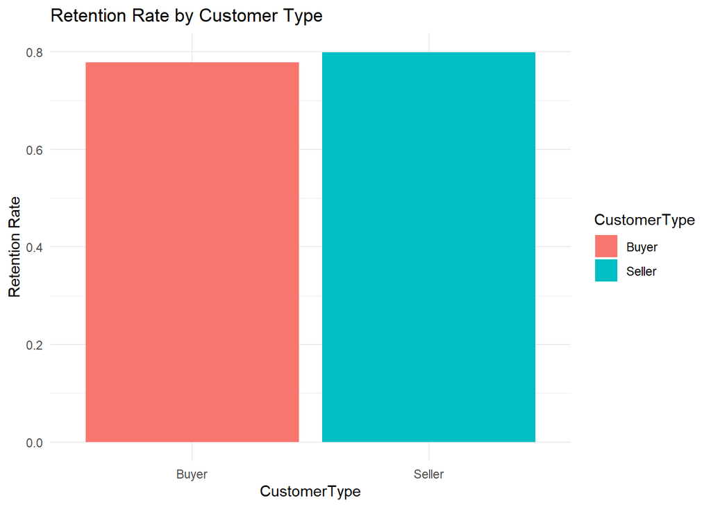

```r
# Bar plot for Retention Rates by Customer Type
ggplot(retention_summary, aes(x = CustomerType, y = RetentionRate, fill = CustomerType)) +
  geom_bar(stat = "identity") +
  labs(title = "Retention Rate by Customer Type", y = "Retention Rate") +
  theme_minimal()
```

[output not shown]